# Combined Model and Figure Output

Sarah Supp

01/25/2016

This document outputs the results and figures for the manuscript titled “Winter conditions influence biological responses of migrating hummingbirds”, by Catherine H. Graham, Sarah R. Supp, Donald R. Powers, Pieter Beck, Marisa C.W. Lim, Anusha Shankar, Tina Cormier, Scott Goetz, and Susan M. Wethington

The script uses migratory capture data for Broad-tailed Hummingbird (BTHU) at sites in southeastern Arizona and remote-sensing data for NDVI (proxy for food resources) and temperature (converted to operative temperature) at known wintering locations in high-elevation Mexico.

## Import Libraries and Source Code scripts

## Data

There are several main datasets that need to be imported to run the final analysis and generate the figures for 2001-2012:

1. HMN migration season capture data (arrival, molt, body mass and body fat data)
2. Winter climate summary data

```r
# If you want to see the raw HMN data - we use a subset of this data, for March-June sampling sessions, defined by S. Wethington
rawdat = read.csv("/home/sarah/Documents/GitHub/extreme_limits/data/HMN_AZ_low&mid_elev_BTLH2002-2012.csv")

# Migration: HMN capture and measurement data for sites sampled March-early June
load("/home/sarah/Documents/GitHub/extreme_limits/data/site.dat.rdata")

# Winter: weather data summarized for NDVI and temperature
load("/home/sarah/Documents/GitHub/extreme_limits/data/yearly.climate.rdata")
```

Ensure that the site data columns are the correct type (e.g. factor, numeric, Date) for analysis, and create a simplified molt class

```r
#make an ordered categorical variable describing primary molt using all the classes, and using a simplified version (3 classes)
ordermolt <- function(x){ordered(x, levels=c("M","R",1:8,0,9,"F","L"))}
site.dat$PriMary.Molt <- ordermolt(site.dat$PriMary.Molt)

#simplify molt to 3 categories (M-8 = early, 9-0 = late, F-L = complete), as requested by the reviewer
site.dat$PriMary.Molt3 <- as.character(site.dat$PriMary.Molt)
site.dat$PriMary.Molt3[site.dat$PriMary.Molt3 %in% c("M", "R", "1", "2", "3", "4", "5", "6", "7", "8")] <- "early"
site.dat$PriMary.Molt3[site.dat$PriMary.Molt3 %in% c("9", "0")] <- "late"
site.dat$PriMary.Molt3[site.dat$PriMary.Molt3 %in% c("F", "L")] <- "complete"

ordermolt3 <- function(x){ordered(x, levels = c("early", "late", "complete"))}
site.dat$PriMary.Molt3 <- ordermolt3(site.dat$PriMary.Molt3)

#calculate date as julian day of the year
site.dat$jday <- yday(site.dat$date)
```

## Exploring the Migration Data

### *BTHU Arrival at southeastern Arizona sites*

Let’s plot the distribution of arrival dates across all the sites using the raw data:

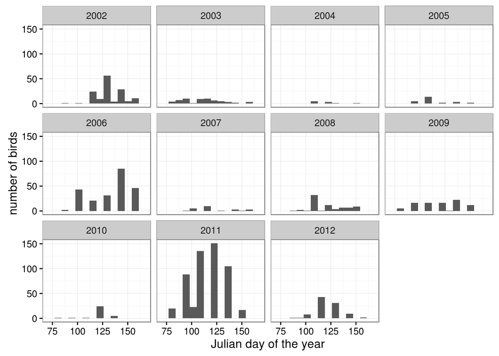

```r
#plot arrival dates by year
ggplot(site.dat, aes(jday)) + geom_histogram(binwidth=7) + xlab("Julian day of the year") + ylab("number of birds") +
 theme_bw() +  facet_wrap(~yearfac)
```

First, let’s calculate the arrival quantiles for the migrating birds at each site and year

```r
#keep only the variables you need
arrival.dat <- site.dat[, c("LOC", "date", "yearfac", "mofac")]

getARRIVALquant <- function(quantile.){
  tapply(arrival.dat$date, INDEX=list(arrival.dat$LOC, arrival.dat$yearfac),
        FUN=quantile, type=1, probs=c(quantile.), na.rm=T)}

ARR.quant.05 <- as.Date(as.vector(getARRIVALquant(.05)), origin="1970-01-01")
ARR.quant.25 <- as.Date(as.vector(getARRIVALquant(.25)), origin="1970-01-01")
ARR.quant.50 <- as.Date(as.vector(getARRIVALquant(.50)), origin="1970-01-01")
ARR.quant.75 <- as.Date(as.vector(getARRIVALquant(.75)), origin="1970-01-01")
ARR.quant.95 <- as.Date(as.vector(getARRIVALquant(.95)), origin="1970-01-01")

ARR.quants <- cbind.data.frame(ARR.quant.05, ARR.quant.25, ARR.quant.50, ARR.quant.75, ARR.quant.95)

# Calculate variables to hold the site names ('LOC') and years ('yr') associated with the quantiles
quant.temp <- tapply(site.dat$date, INDEX=list(site.dat$LOC, site.dat$yearfac),
       FUN=quantile, type=1, probs=c(.05), na.rm=T)

LOC <- rownames(quant.temp)
yr <- rep(colnames(quant.temp), each=length(LOC))

# Calculate the number of birds in each sample ('n.birds') (number of birds at each site in each year)
n.birds <- as.vector(tapply(site.dat$date, INDEX=list(site.dat$LOC, site.dat$yearfac),
                 FUN=function(x){length(which(!is.na(x)))}))

# Save the new molt quantile data into a new data.frame called MOLT.quants
ARR.quants <- cbind.data.frame(LOC, yr, n.birds, ARR.quants)
ARR.quants <- ARR.quants[complete.cases(ARR.quants),]

# Make sure n.birds is numeric
ARR.quants$n.birds <- as.numeric(ARR.quants$n.birds)

# Add a column that converts the median date (ARR.quant.50) to Julian date (so they can be compared regardless of year)
ARR.quants$jday.50 <- yday(ARR.quants$ARR.quant.50)

# remove variables from the memory that are no longer needed
rm(quant.temp, ARR.quant.05, ARR.quant.25, ARR.quant.50, ARR.quant.75, ARR.quant.95, n.birds, LOC, yr)
```

The number of birds captured at each site across the time series:

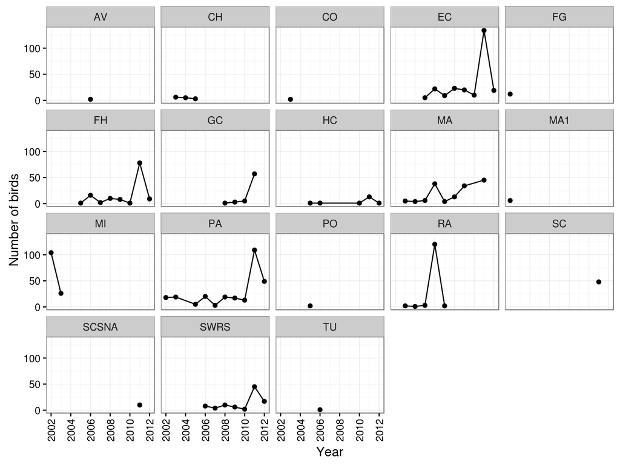

For the arrival data, we will use the median arrival data at a given site and year as our main response variable. This is calculated 50th quantile of the arrival distribution. Date is plotted here as Julian Day of the Year, so month-day can be compared regardless of year.

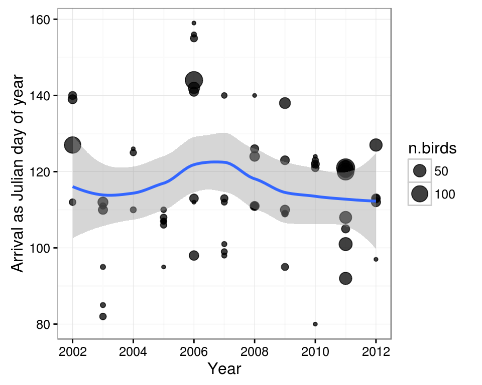

Values for the 50th quantile (median) arrival date ranged from 80 to 159 with a mean arrival date of 4-26. In 2006, the mean arrival date was 5-16 and 2003 it was 4-10.

### *BTHU Molt Stage for primary (flight) feathers*

Although molt stage was observed across the entire body of the hummingbird, the molt stage of primary feathers is the most relevant to migration. Hummingbirds molt their primary feathers in order, so this variable is treated as an ordered factor ( M, R, 1, 2, 3, 4, 5, 6, 7, 8, 10, 9, F, L ) where M and R represent unmolted feathers (moderate wear and ragged) and F and L represent completed molt (fresh and light wear). stages 1-8 are considered early molt, and 10-9 is considered to be late molt. In general, migrating BTHU were usually captured in late or completed molt stages.

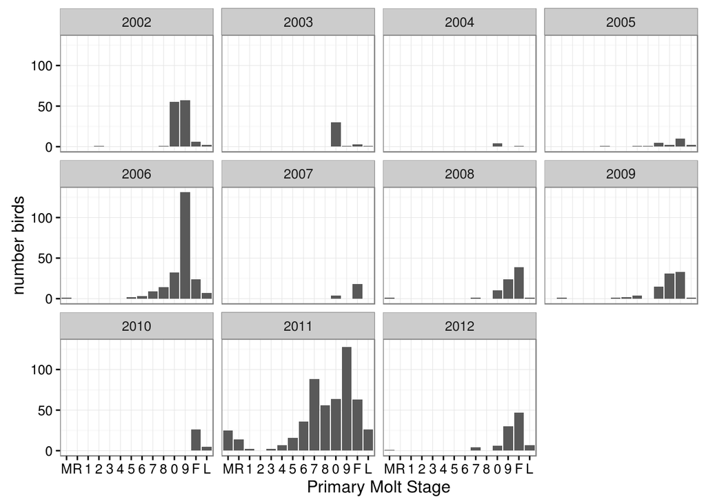

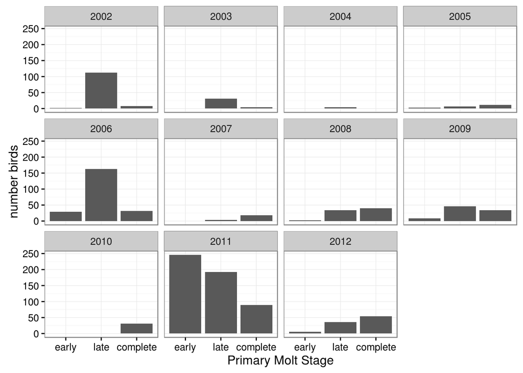

Similar to arrival, we calculated the median molt stage for birds at a given site and year as our response variable, as the 50th quantile of the molt distribution, using ALL the molt classes (n=14) and using a simplified version of molt classes (n=3).

The median molt stages for BTHU included later stages of early molt, late molt, and completed molt (all stages represented: 7-L).

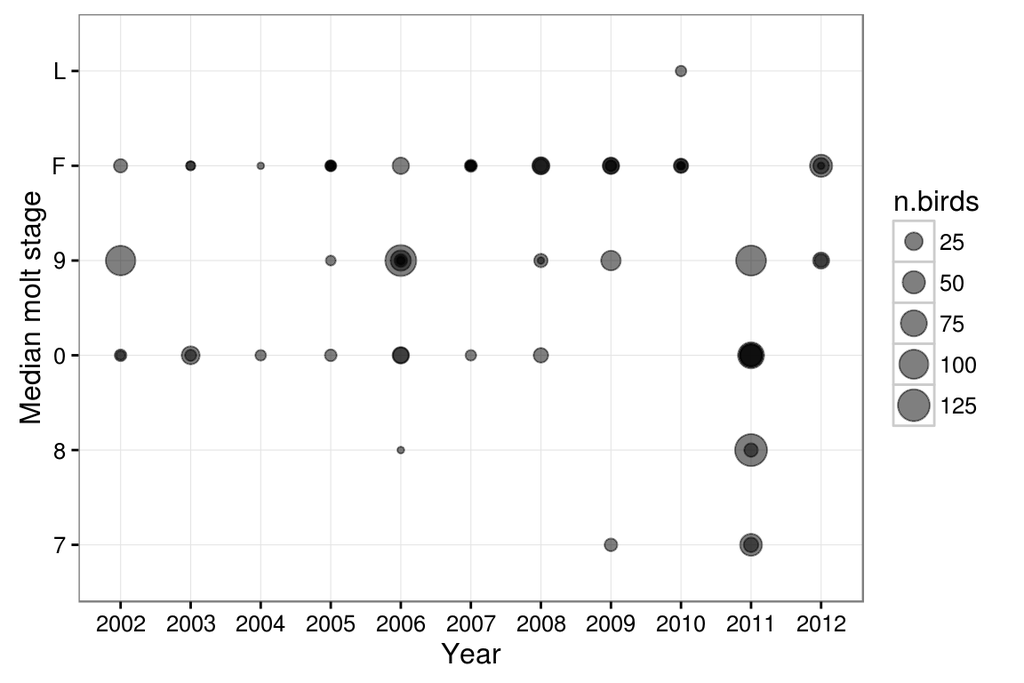

Birds were most commonly found in late molt stages (10-9; 42.19 %) and in completed molt (F-L; 48.44 %) compared to premolt and early molt stages (M-8; 9.38 %). The weighted average molt stage observed across the sites and years was 9 (late molt).

The median molt stages for BTHU included later stages of early molt (M-8), late molt (9-0), and completed molt (F-L).

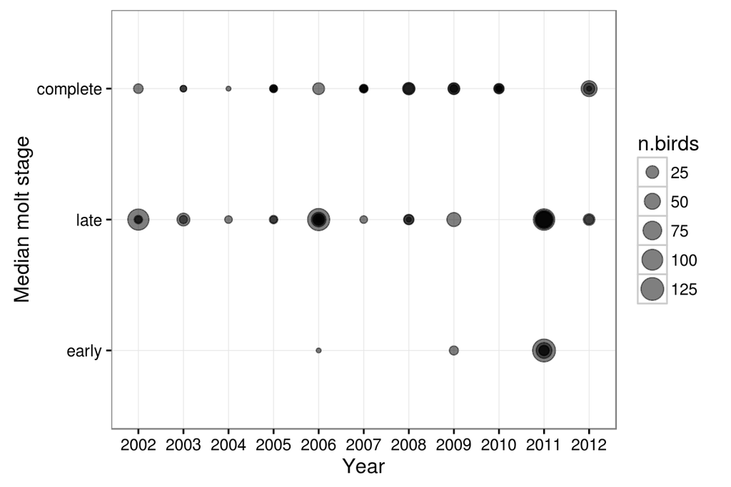

Using the simplified version of molt, BTHU were most commonly found in late molt stages (10-9; 42.19 %) and in completed molt (F-L; 48.44 %) compared to premolt and early molt stages (M-8; 9.38 %).

### *BTHU Migratory Body Mass and Fat Scores*

Hummingbirds are able to gain and lose body mass and fat in a short period of time, depending on their access to food resources and their energetic expenditure. Thus, the mass and fat of a hummingbird likely depends on environmental conditions at a much shorter timescale (hours or days) than the time between the winter and migratory seasons. However, weight and fat of a bird during the winter may have an impact on hummingbird’s ability to undergo molt or it’s decision to migrate.

Body fat scores for hummingbirds are treated as an ordered factor (0, T, 1, 2, 3).

Body fat and mass are positively correlated.

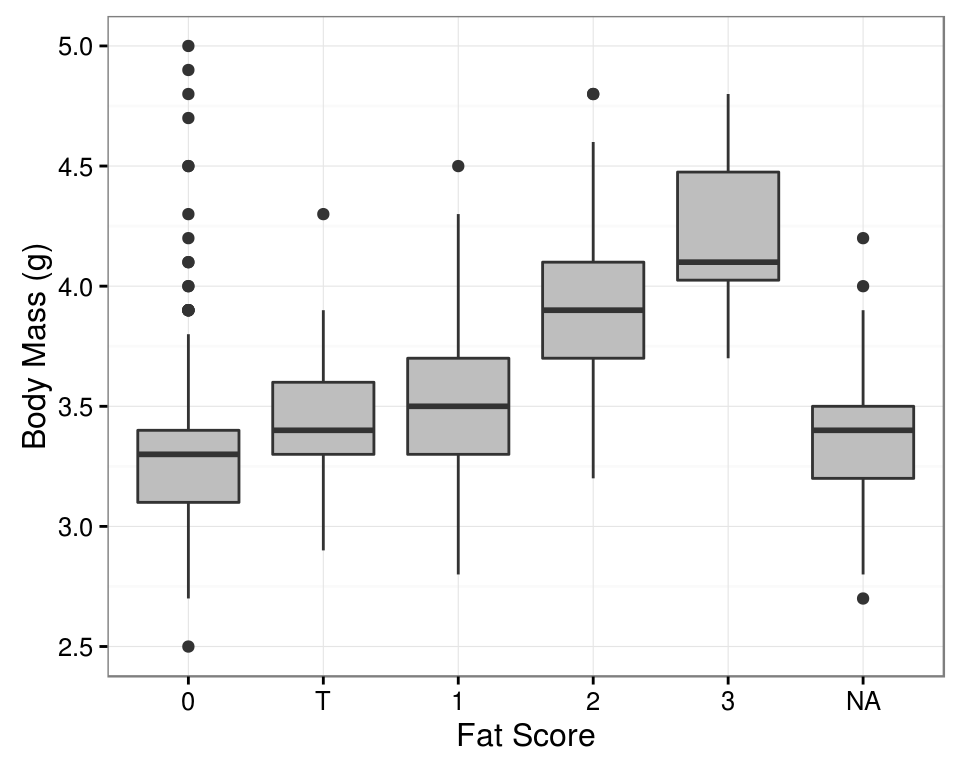

BTHU body mass:

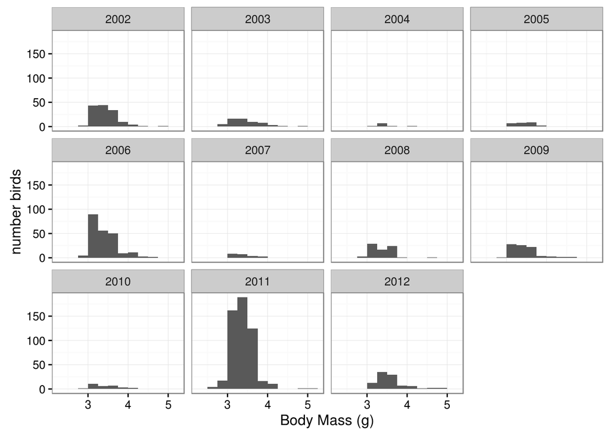

```r
#plot body mass by year for comparison
ggplot(body.dat, aes(Weight)) + geom_histogram(binwidth=0.25) + xlab("Body Mass (g)") + ylab("number birds") +
 theme_bw() +  facet_wrap(~yearfac)
```

```r
mass.mean <- round(mean(body.dat$Weight, na.rm=T), 2)
mass.range <- range(body.dat$Weight, na.rm=T)
mass.sd <- round(sd(body.dat$Weight, na.rm=T), 2)
```

Migrating BTHU bodymass ranges from 2.5 - 5 grams with a mean of 3.39 (sd= 0.3) grams.

BTHU body fat

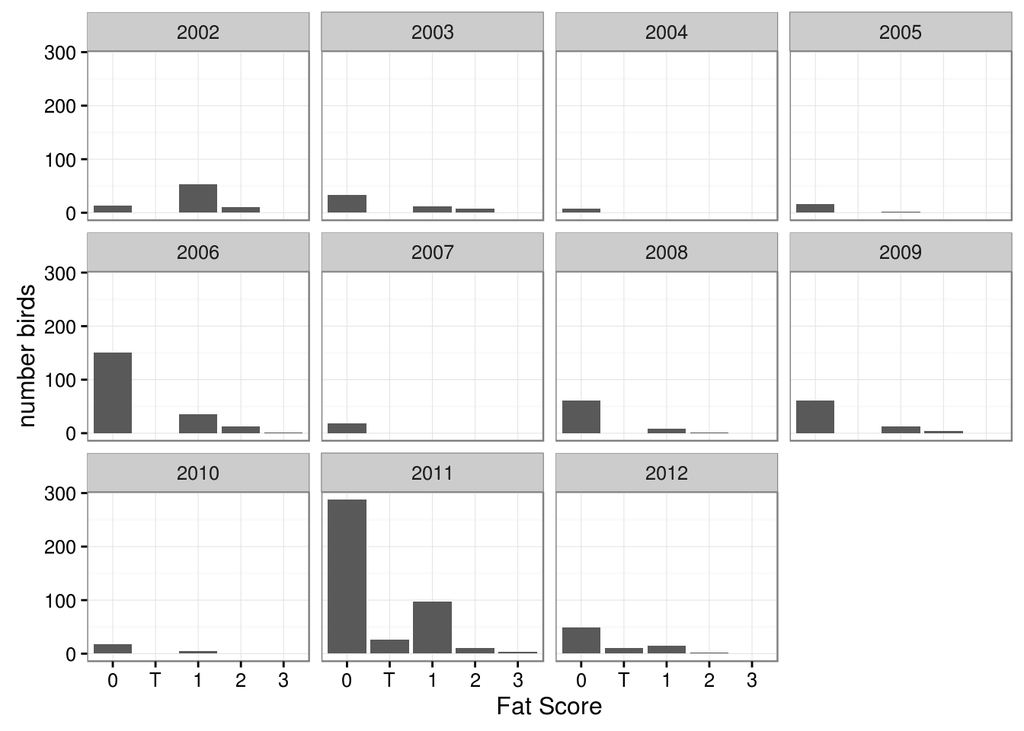

```r
#plot body fat by year for comparison
body.dat.cc <- body.dat[complete.cases(body.dat),]
ggplot(body.dat.cc, aes(Fat)) + geom_bar() + xlab("Fat Score") + ylab("number birds") +
 theme_bw() +  facet_wrap(~yearfac)
```

```r
fatscores <- table(body.dat$Fat)
```

Most BTHU were observed with low fat (0; 68.34 %) or a medium amount of fat (1; 22.94 %).

Bodymass did not show a strong relationship to molt:

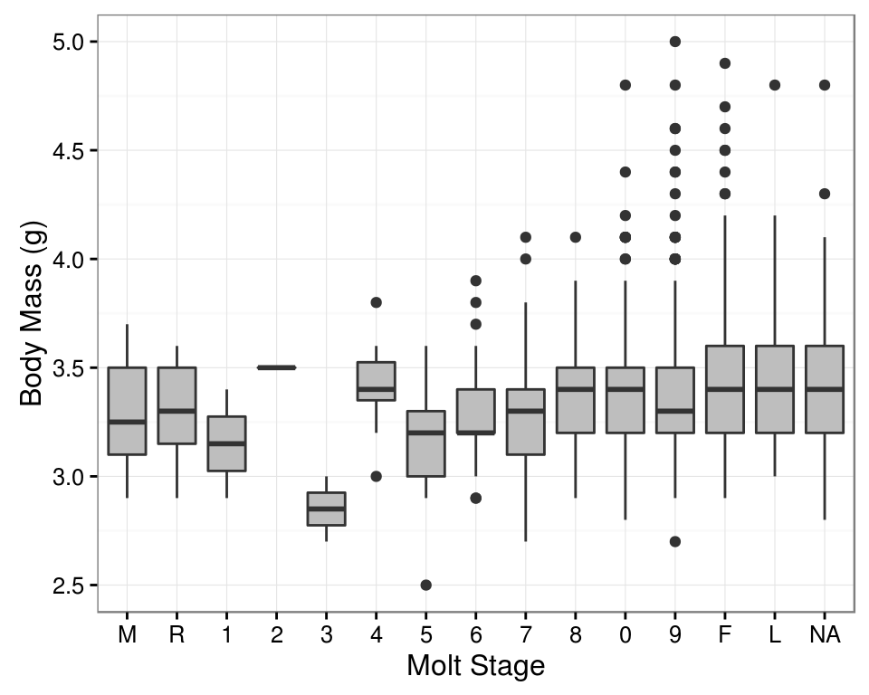

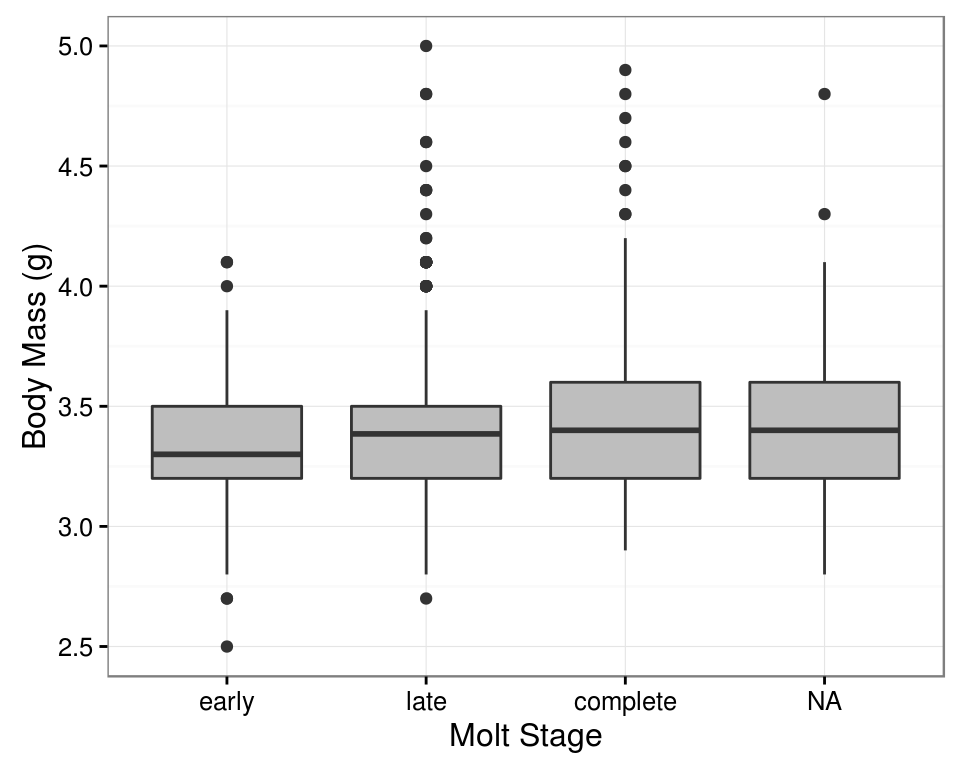

### *Winter Climate Data, summarized for each year*

We defined winter locations for BTHU by querying GBIF for records from 1936-2011 that occurred above an elevation of 1500 m for November 15 - March 15 (known winter distributional limits; Calder and Calder 1992, Pyle 1997). For all 201 locations meeting these criteria, we downloaded remote sensing variables for winter resources (NDVI and cumulative precipitation; 1 km resolution, interpolated to daily; MODIS and CFSv2 datasets) and winter thermal demand (percentile of 6-hour periods where operative temperature was < 10 C; 20 km resolution; NCEP and CFSv2 datasets; Greek et al. 1989, Walsberg 1995). Winter variables were summarized across the 201 sites as the mean winter NDVI, cumulative winter precipitation, and the percentile of daily operative temperatures at or below 10 C.

A “bad” winter for a hummingbird could occur if:

1. Resources are lower than average
2. Temperatures are colder than average
3. Resources are lower than average and temperatures are colder than average (worst case scenario)

Average winter NDVI was positively correlated with cumulative precipitation, so we chose to use NDVI as our proxy for winter resources.

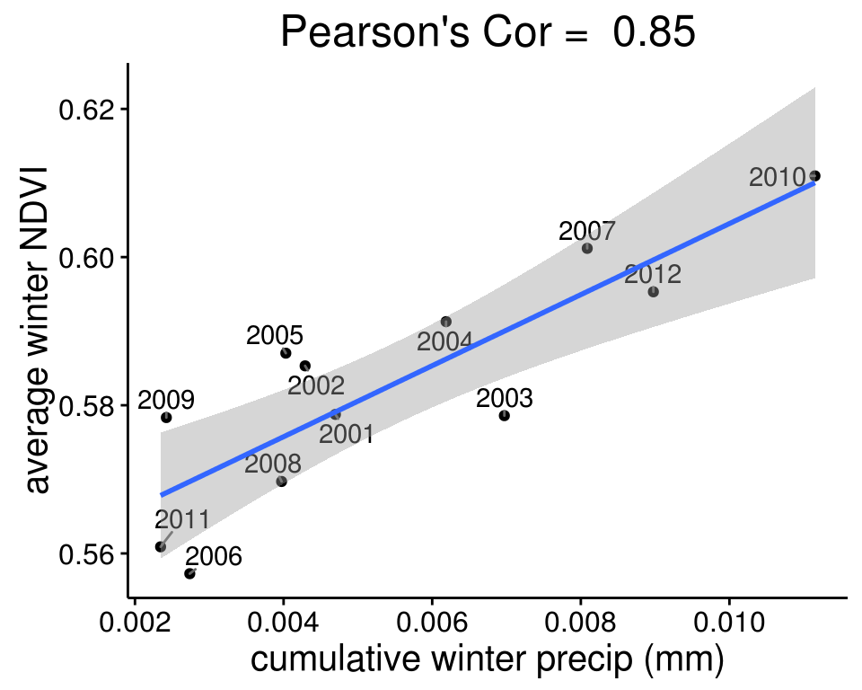

NDVI and operative temperature were not significantly correlated, although there were some years when the percentile of daily operative temperatures was particularly high and NDVI was particularly low.

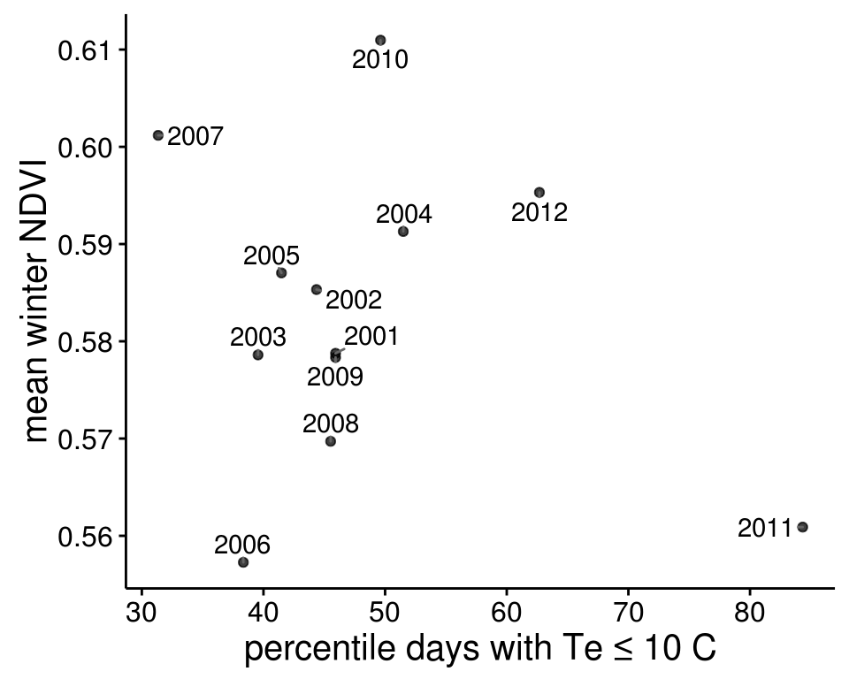

## Biological Response (Winter environment + Migration behavior and physiology)

```r
# Combine each of the response variable datasets with the climate data for analysis
# yearly.catch.stat <- merge(yearly.catch.stat, yearly.climate)                          # arrival
# yearly.molt.stat <- merge(x=MOLT.quants, y=yearly.climate, by='yr')                    # molt
# yearly.weight.stat <- merge(x=body.dat, y=yearly.climate, by.x='yearfac', by.y='yr')   # mass & fat
```

```r
# Combine each of the response variable datasets with the climate data for analysis
yearly.arrival.stat <- merge(x=ARR.quants, y=yearly.climate, by='yr')                  # arrival
yearly.molt.stat <- merge(x=MOLT.quants, y=yearly.climate, by='yr')                    # molt (using all classes)
yearly.molt3.stat <- merge(x=MOLT.quants.3, y=yearly.climate, by='yr')                 # molt (using 3 classes)
yearly.weight.stat <- merge(x=body.dat, y=yearly.climate, by.x='yearfac', by.y='yr')   # mass & fat
```

We can summarize the responses of all the variables together, without distinguishing for site-level effects. In general, winters with lower NDVI (resource proxy) were correlated with later migration arrival date and earlier stage molt. Winters with more cold periods were correlated with earlier stage molt, but didn’t have a strong relationship to timing of arrival. There were not significant correlations among the mass and fat variables for migrating BTHU and the winter environmental predictor variables.

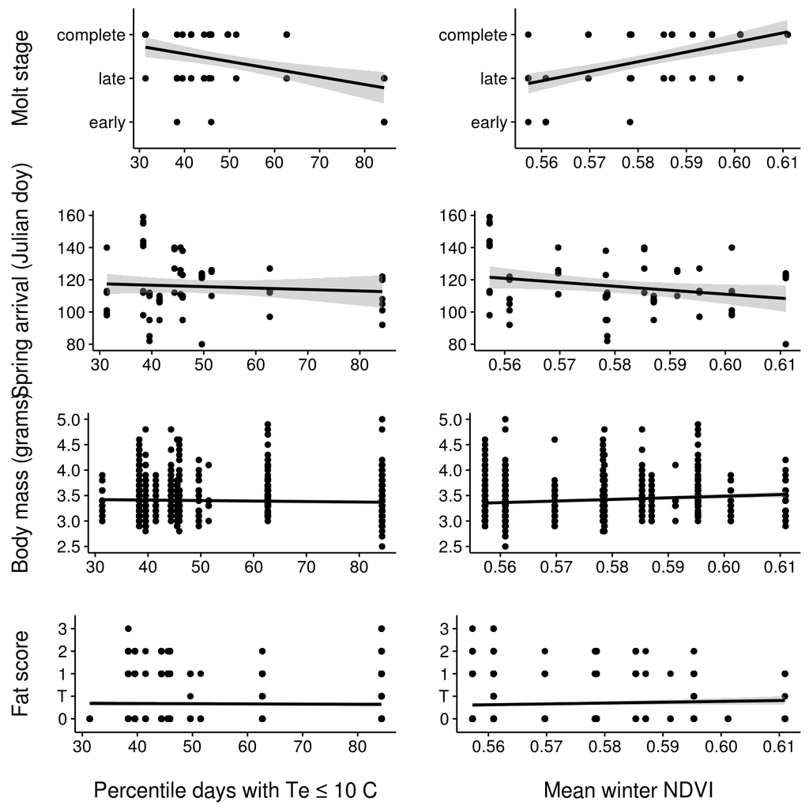

## Biological Response Models and results

We used a function (mod.evaluation.R) to evaluate [hierarchical models](http://www.quantpsy.org/interact/interactions.htm) of **median arrival (50th quantile)** as a linear function of annual physiological demand (percentile daily Te < 10 C) and resource availability (mean winter NDVI), allowing for a random intercept associated with ‘site’. Here we treat arrival date as ‘numeric’.

```r
attach(yearly.arrival.stat)

me_arr <- mod.evaluation(yname='jday.50', centering='CGM', standardisation=T,
               ordered.fac.treatment = "as.num", log.D=T,
               R="winterNDVI", D="yearly.Te.10C.q")
```

```
## samples will be weighted by 'n.birds' in model calibration
## DEMAND variable will be log-transformed
##
## Correlation between D and R (after transform and or subset):
##
##  Pearson's product-moment correlation
##
## data:  D and R
## t = -2.1312, df = 66, p-value = 0.0368
## alternative hypothesis: true correlation is not equal to 0
## 95 percent confidence interval:
##  -0.46409827 -0.01631334
## sample estimates:
##        cor
## -0.2537515
##
##
## Predictor variables were centered at the grand mean (CGM)
##
## Predictor variables were standardised using grand sd
```

```
## Conditional effects of predictors in full model, i.e. including R*D interaction
```

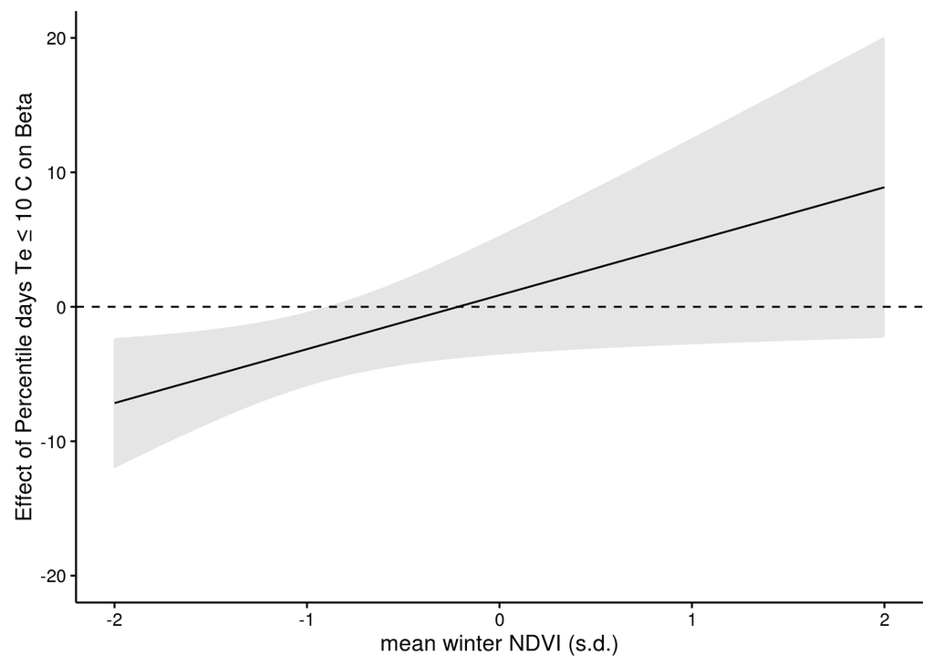

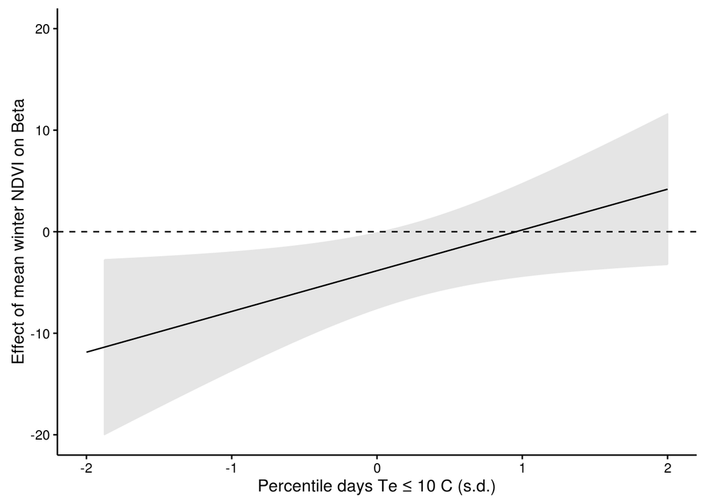

```
## Calculating fixed-effects R2
## Calculating psuedo R2 for numeric response variable
## Calculating Lefcheck (Nakagawa & Schielzeth) marginal and conditional R2
## AIC of best model: 588.5275
## There were 68 observations and 18 groups in the model.
## Model evaluation completed and tabulated:
```

```r
detach(yearly.arrival.stat) #Used to be with yearly.catch.stat, n.birds needs to weighted.
me_arr[[1]]
```

```
##         mod.name dAICc.lib dAICCc.con df A.weight.lib D_low D_high R_low
## mod.DR    mod.DR       0.0        0.0  6            1 -3.48   5.21 -7.56
## mod.D_R  mod.D_R       5.1        2.9  5            0 -5.47   0.01 -6.49
## mod.D      mod.D       8.1        4.2  4            0 -4.29   0.75    NA
## mod.R      mod.R       8.5        4.7  4            0    NA     NA -4.73
## mod.0      mod.0       9.8        4.8  3            0    NA     NA    NA
##         R_high DR_low DR_high D_est R_est DR_est     SE_D     SE_R
## mod.DR   -0.11   0.33     7.7  0.87 -3.84   4.01 2.219090 1.899595
## mod.D_R   0.89     NA      NA -2.73 -2.80     NA 2.219090 1.883626
## mod.D       NA     NA      NA -1.77    NA     NA 1.287374       NA
## mod.R     1.99     NA      NA    NA -1.37     NA       NA 1.714729
## mod.0       NA     NA      NA    NA    NA     NA       NA       NA
##            SE_DR fixefR2      pseudR2   MarginalR2 ConditonalR2
## mod.DR  1.879674      20  0.160925616 0.0129568664   0.04157063
## mod.D_R       NA      14  0.060579003 0.0046081149   0.03789869
## mod.D         NA      10 -0.032520249 0.0012642320   0.03953549
## mod.R         NA      12 -0.005321522 0.0007632884   0.05273365
## mod.0         NA      10 -0.052598864 0.0000000000   0.05139533
```

**Molt as 3 classes:** We used the function (mod.evaluation.R) to evaluate [hierarchical models](http://www.quantpsy.org/interact/interactions.htm) of **median molt stage (50th quantile)** as a linear function of annual physiological demand (percentile daily Te < 10 C) and resource availability (mean winter NDVI), allowing for a random intercept associated with ‘site’. Here, we treat molt stage as ‘binomial’ since the distance between categories is not assumed to be constant. See the *methods* section of the manuscript for more details.

```r
# run the model using the 3 molt classes only
attach(yearly.molt3.stat)
me_molt3 <- mod.evaluation(yname='MOLT.quant.50', centering='CGM', standardisation=T,
               ordered.fac.treatment = "as.binomial", log.D=T,
               R="winterNDVI", D="yearly.Te.10C.q")
```

```
## samples will be weighted by 'n.birds' in model calibration
## DEMAND variable will be log-transformed
##
## Correlation between D and R (after transform and or subset):
##
##  Pearson's product-moment correlation
##
## data:  D and R
## t = -2.115, df = 62, p-value = 0.03845
## alternative hypothesis: true correlation is not equal to 0
## 95 percent confidence interval:
##  -0.47493793 -0.01453099
## sample estimates:
##        cor
## -0.2594137
##
##
##  MOLT.quant.50  is an ordered factor. options are to treat as numeric or in a binomial fashion !!!
## MOLT.quant.50  is an ordered factor and will be converted to a count table !!!
##
## Predictor variables were centered at the grand mean (CGM)
##
## Predictor variables were standardised using grand sd
```

```
## Conditional effects of predictors in full model, i.e. including R*D interaction
```

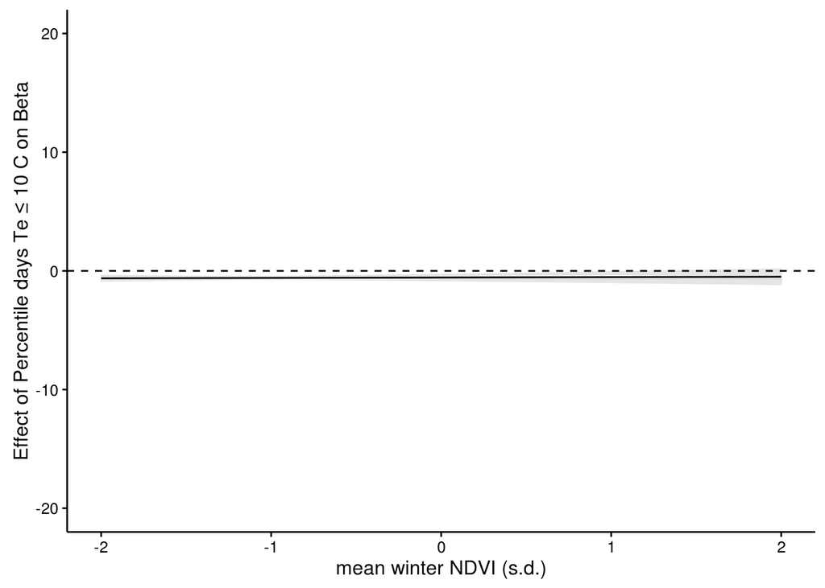

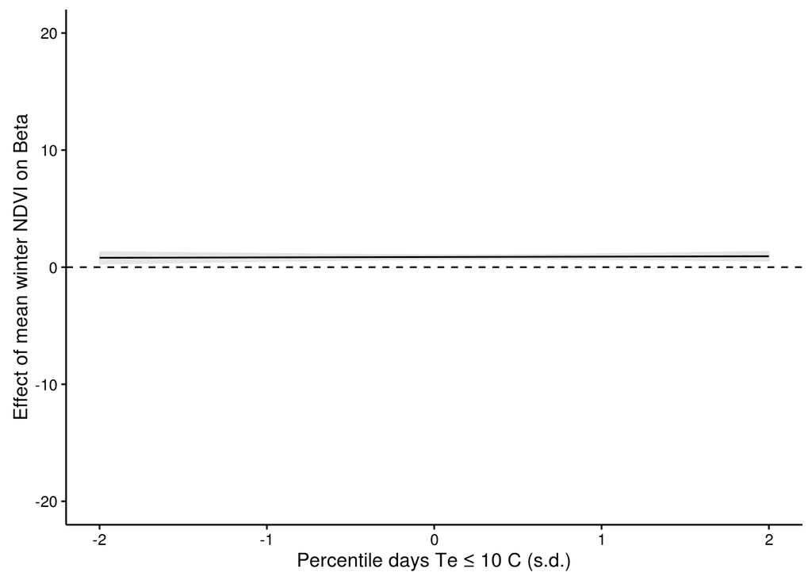

```
## Calculating psuedo R2 for binomial response variable
## Calculating Lefcheck (Nakagawa & Schielzeth) marginal and conditional R2
## AIC of best model: 1688.311
## There were 128 observations and 17 groups in the model.
## Model evaluation completed and tabulated:
```

```r
detach(yearly.molt3.stat)
me_molt3[[1]]
```

```
##         mod.name dAICc.lib dAICCc.con df A.weight.lib D_low D_high R_low
## mod.D_R  mod.D_R       0.0        0.0  4         0.99 -0.70  -0.49  0.71
## mod.DR    mod.DR       2.3        4.0  5         0.01 -0.80  -0.32  0.69
## mod.R      mod.R     124.4      123.2  3         0.00    NA     NA  1.02
## mod.D      mod.D     125.4      124.2  3         0.00 -0.93  -0.72    NA
## mod.0      mod.0     406.5      404.5  2         0.00    NA     NA    NA
##         R_high DR_low DR_high D_est R_est DR_est       SE_D       SE_R
## mod.D_R   1.05     NA      NA -0.60  0.88     NA 0.12382231 0.08541206
## mod.DR    1.05  -0.17    0.24 -0.56  0.87   0.03 0.12382231 0.09120563
## mod.R     1.34     NA      NA    NA  1.18     NA         NA 0.08336866
## mod.D       NA     NA      NA -0.82    NA     NA 0.05356824         NA
## mod.0       NA     NA      NA    NA    NA     NA         NA         NA
##             SE_DR   pseudR2 MarginalR2 ConditonalR2
## mod.D_R        NA 0.1965170  0.2102597    0.5046305
## mod.DR  0.1051503 0.1965627  0.2038004    0.4998809
## mod.R          NA 0.1359369  0.1986120    0.5306226
## mod.D          NA 0.1354531  0.1099216    0.4668992
## mod.0          NA 0.0000000  0.0000000    0.4870754
```

We used the function (mod.evaluation.R) to evaluate [hierarchical models](http://www.quantpsy.org/interact/interactions.htm) of **body mass** as a linear function of annual physiological demand (percentile daily Te < 10 C) and resource availability (mean winter NDVI), allowing for a random intercept associated with ‘site’. Here, we treat body mass as numeric.

```r
attach(yearly.weight.stat)
#http://www.quantpsy.org/interact/interactions.htm
mod.evaluation(yname='Weight', centering='CGM', standardisation=T,
               ordered.fac.treatment = "as.num", log.D=T,
               R="winterNDVI", D="yearly.Te.10C.q", N=NULL)
```

```
## all samples will be equally weighted calibration
## DEMAND variable will be log-transformed
##
## Correlation between D and R (after transform and or subset):
##
##  Pearson's product-moment correlation
##
## data:  D and R
## t = -13.071, df = 1316, p-value < 2.2e-16
## alternative hypothesis: true correlation is not equal to 0
## 95 percent confidence interval:
##  -0.3859128 -0.2902976
## sample estimates:
##        cor
## -0.3389803
##
##
## Predictor variables were centered at the grand mean (CGM)
##
## Predictor variables were standardised using grand sd
```

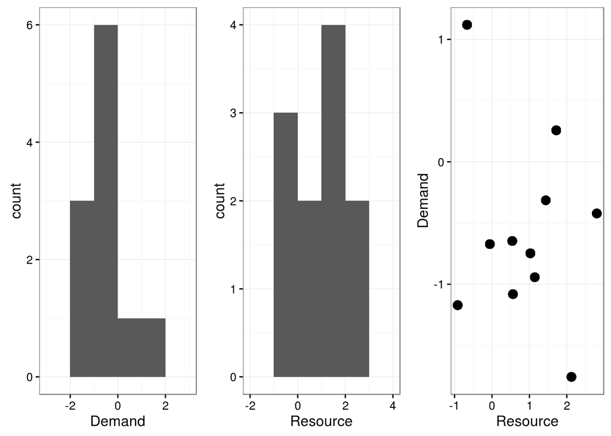

```
## Conditional effects of predictors in full model, i.e. including R*D interaction
```

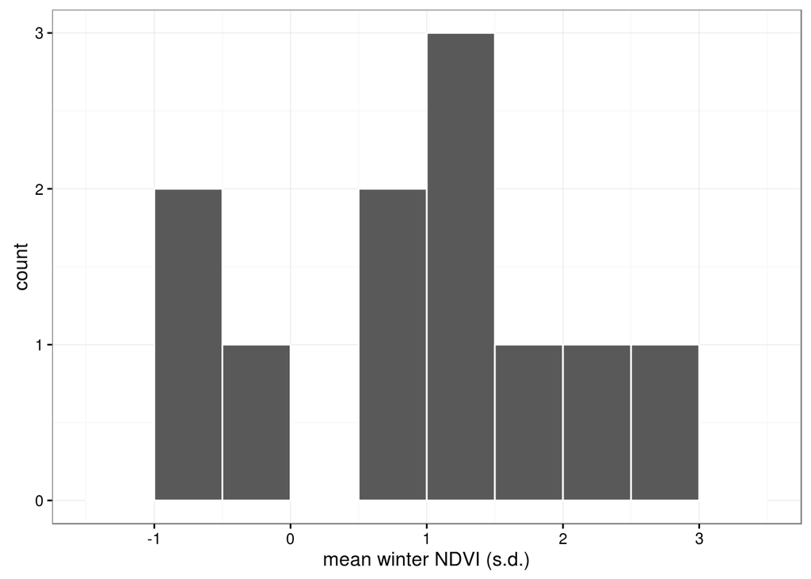

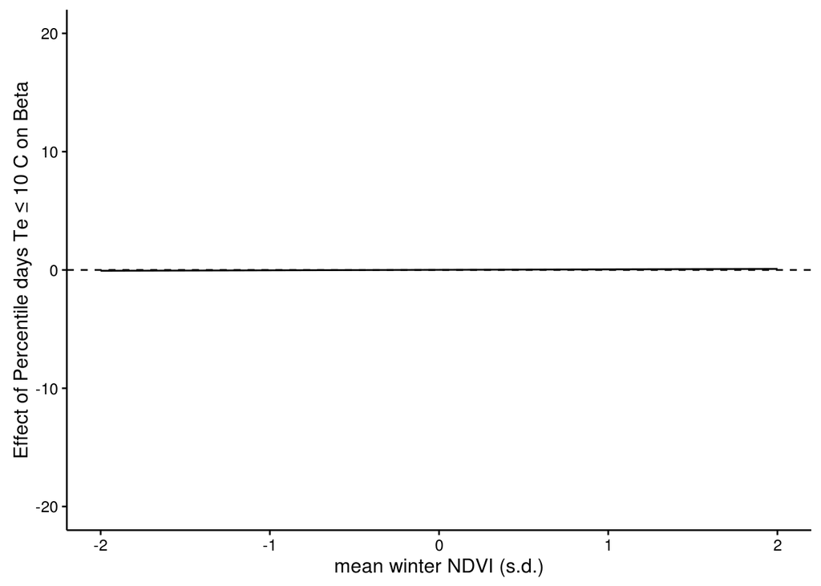

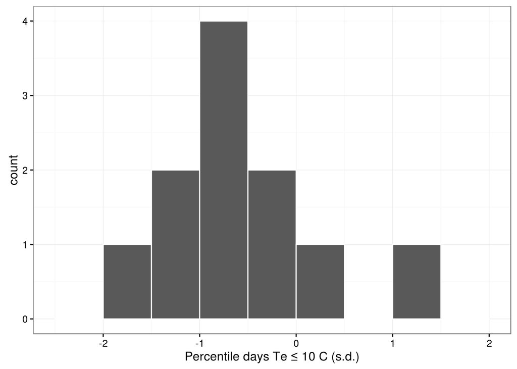

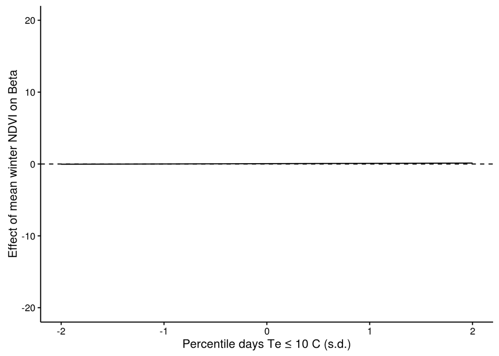

```
## Calculating fixed-effects R2
## Calculating psuedo R2 for numeric response variable
## Calculating Lefcheck (Nakagawa & Schielzeth) marginal and conditional R2
## AIC of best model: 574.1237
## There were 1318 observations and 18 groups in the model.
## Model evaluation completed and tabulated:
```

```
## [[1]]
##         mod.name dAICc.lib dAICCc.con df A.weight.lib D_low D_high R_low
## mod.R      mod.R       0.0        0.0  4            1    NA     NA  0.02
## mod.0      mod.0       4.9        3.6  3            0    NA     NA    NA
## mod.DR    mod.DR       7.8       12.3  6            0 -0.01   0.03  0.03
## mod.D_R  mod.D_R       8.9       10.8  5            0 -0.03   0.01  0.01
## mod.D      mod.D       9.8        9.8  4            0 -0.04   0.00    NA
##         R_high DR_low DR_high D_est R_est DR_est        SE_D        SE_R
## mod.R     0.05     NA      NA    NA  0.03     NA          NA 0.008819144
## mod.0       NA     NA      NA    NA    NA     NA          NA          NA
## mod.DR    0.07   0.02    0.06  0.01  0.05   0.04 0.011131437 0.010624160
## mod.D_R   0.05     NA      NA -0.01  0.03     NA 0.011131437 0.009558158
## mod.D       NA     NA      NA -0.02    NA     NA 0.009449636          NA
##              SE_DR fixefR2    pseudR2  MarginalR2 ConditonalR2
## mod.R           NA       3 0.02722691 0.012930264   0.02110804
## mod.0           NA       3 0.01973558 0.000000000   0.01486329
## mod.DR  0.01239753       4 0.03584201 0.020350342   0.02974187
## mod.D_R         NA       3 0.02809427 0.013104798   0.02223397
## mod.D           NA       3 0.02359547 0.004532142   0.02031177
##
## [[2]]
```

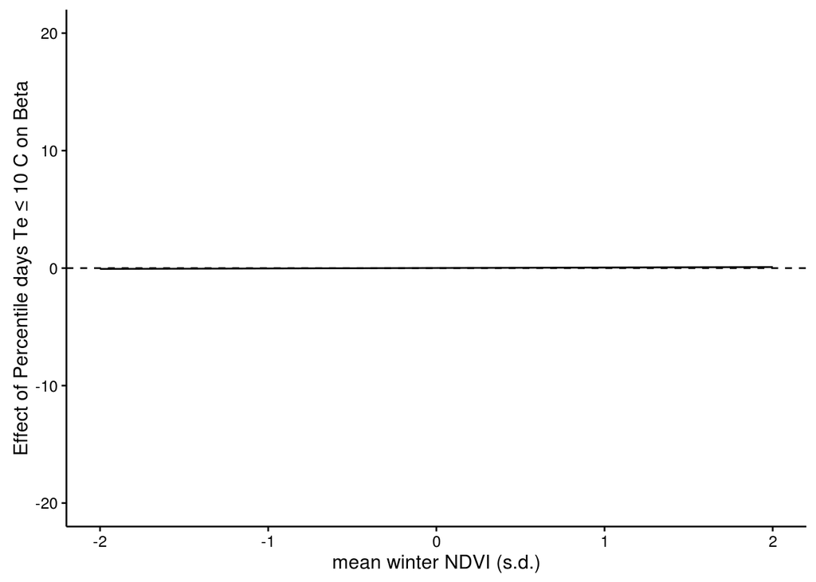

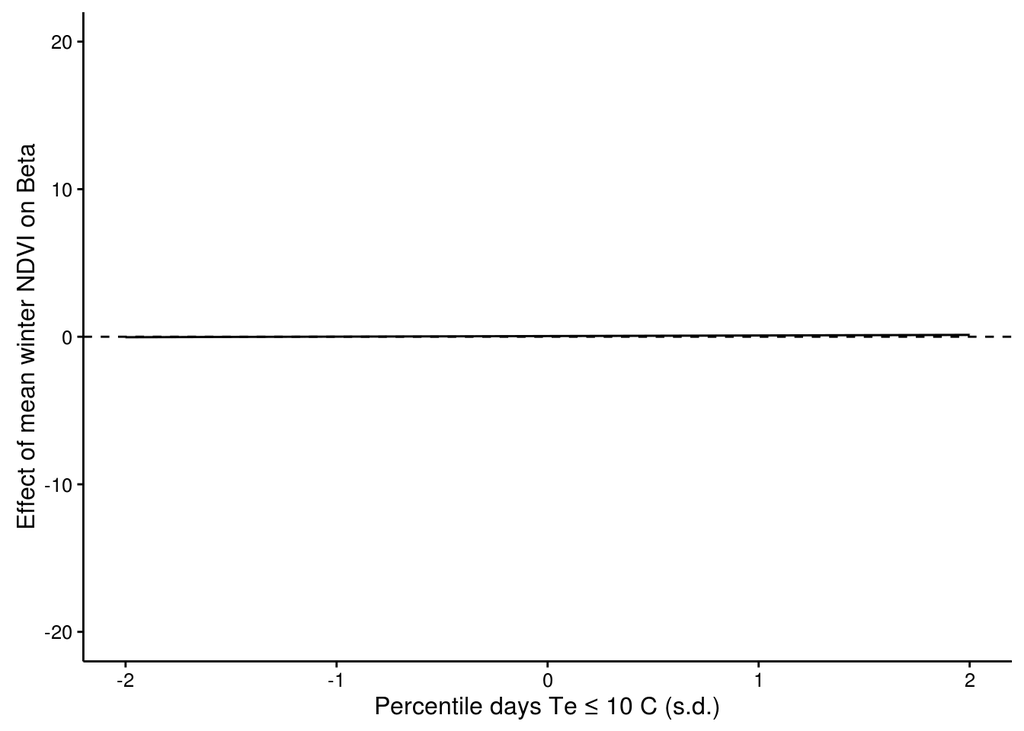

```r
detach(yearly.weight.stat)
```

We used the function (mod.evaluation.R) to evaluate [hierarchical models](http://www.quantpsy.org/interact/interactions.htm) of **fat score** as a linear function of annual physiological demand (percentile daily Te < 10 C) and resource availability (mean winter NDVI), allowing for a random intercept associated with ‘site’. Here, we treat fat score as numeric, since the distance between categories is assumed to be constant.

```r
attach(yearly.weight.stat)
#http://www.quantpsy.org/interact/interactions.htm
mod.evaluation(yname='Fat', centering='CGM', standardisation=T,
               ordered.fac.treatment = "as.num", log.D=T,
               R="winterNDVI", D="yearly.Te.10C.q", N=NULL)
```

```
## all samples will be equally weighted calibration
## DEMAND variable will be log-transformed
##
## Correlation between D and R (after transform and or subset):
##
##  Pearson's product-moment correlation
##
## data:  D and R
## t = -13.071, df = 1316, p-value < 2.2e-16
## alternative hypothesis: true correlation is not equal to 0
## 95 percent confidence interval:
##  -0.3859128 -0.2902976
## sample estimates:
##        cor
## -0.3389803
##
## Fat  is an ordered factor. options are to treat as numeric or in a binomial fashion.
## Fat  will be converted to numeric
##
## Predictor variables were centered at the grand mean (CGM)
##
## Predictor variables were standardised using grand sd
```

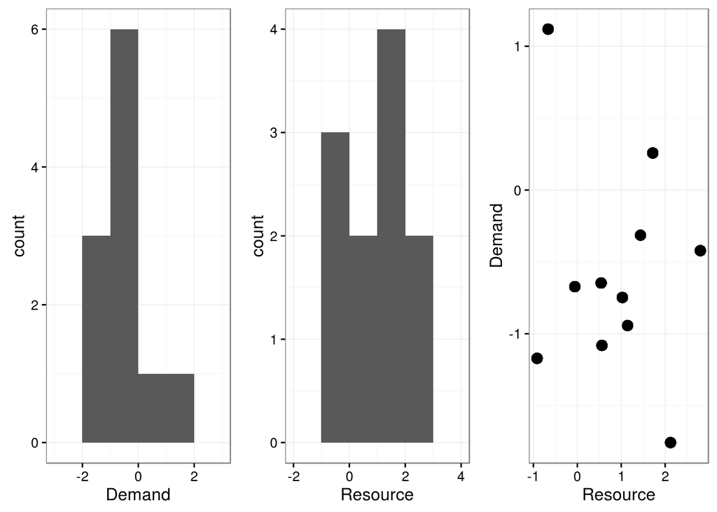

```
## Conditional effects of predictors in full model, i.e. including R*D interaction
```

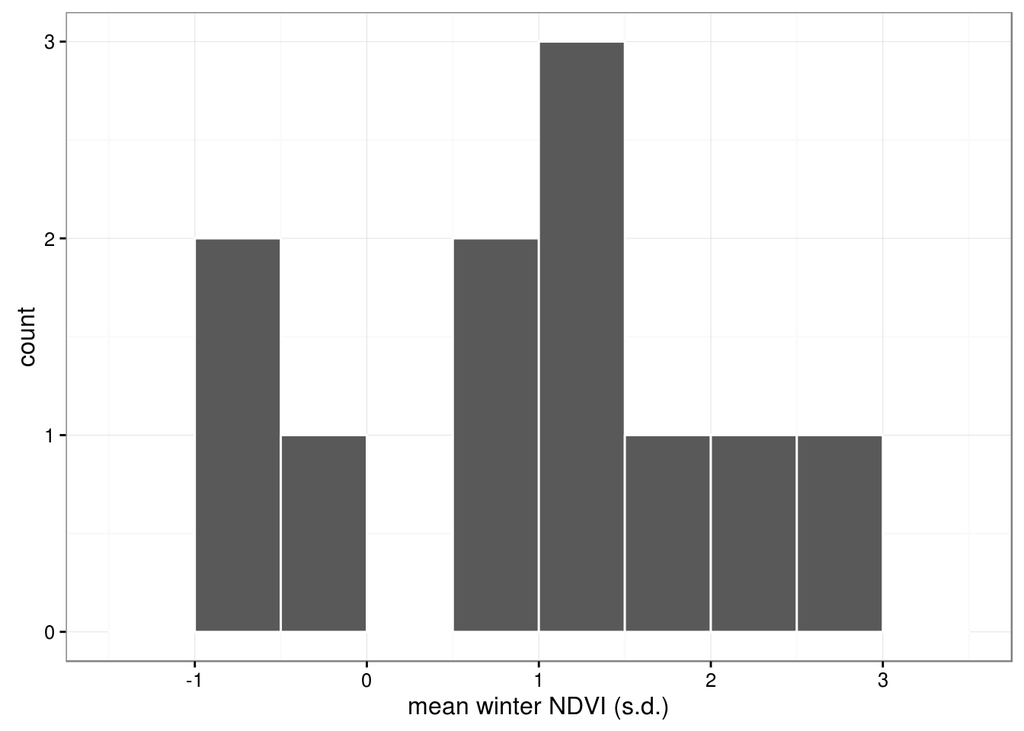

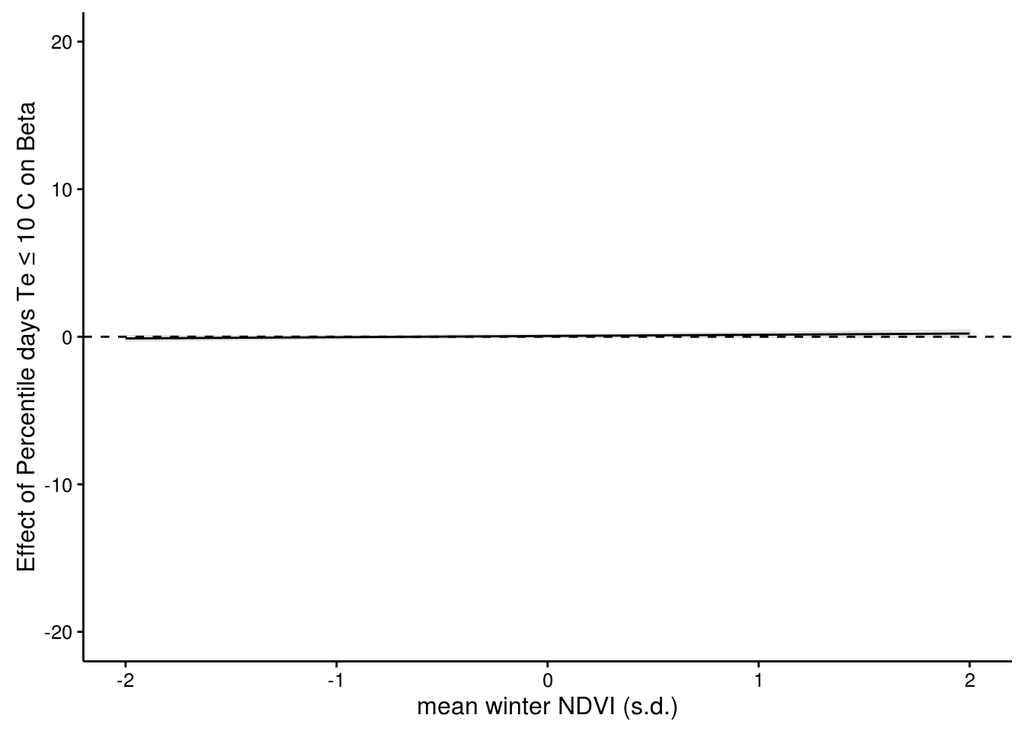

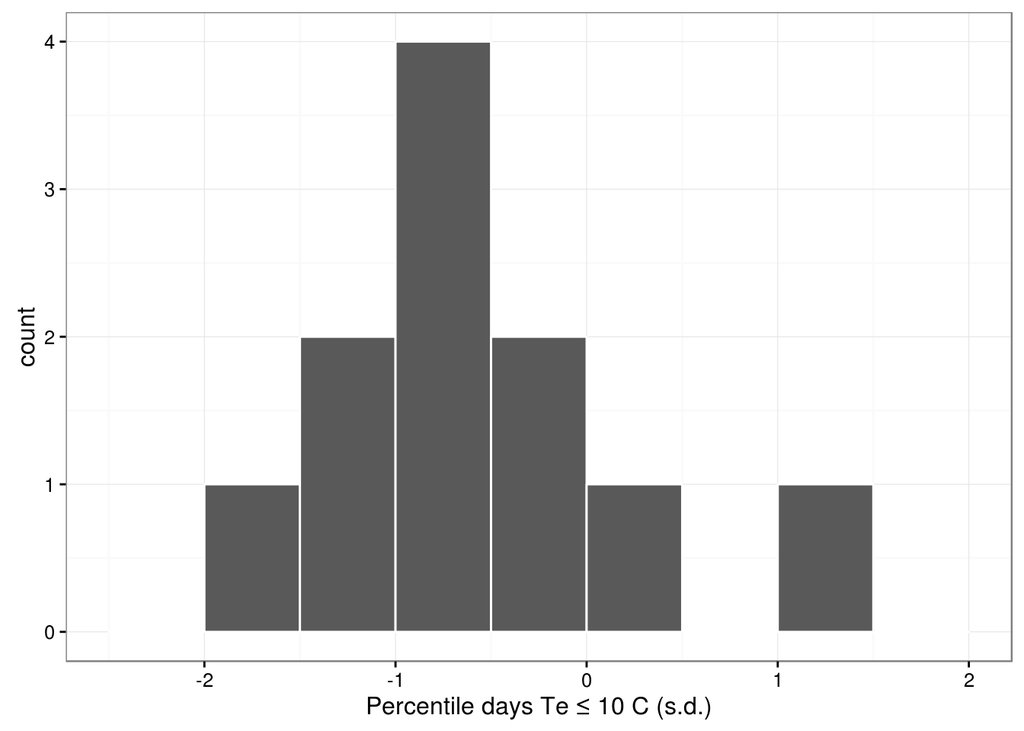